# 5_Airway_CS_NS_meta_analysis

2024-11-13

These scripts analyse the output “linked genes” and “persistent linked genes” from the tumor airways comparisons combined script, and use a meta-analysis approach to give supporting evidence that they are differentially expressed in airways of smokers.

# Making a combined table to rank genes of interest and compare studies

### Read in the linked genes and persistent linked genes

```r
# Read in the linked genes
linked_genes <- read.table('../2_Outputs/6_Linked_genes/A1_TE_TM_linked_genes_0.01_0.1_0.01_0.6_0.01_0.1_20241205.txt', header = TRUE)

# Read in the persistent linked genes
persistent_linked_genes <- read.table('../2_Outputs/6_Linked_genes/A1_TE_TM_A2_persistent_linked_genes_0.05_0_0.05_0_0.05_0_20241205.txt', header = TRUE)
```

## Read in airway DEGs from all datasets

```r
## Read in the tables

GSE4302_CS_NS_GEO2R_limma_sig <- read.table("../2_Outputs/1_Airway_DEGs/GSE4302_CS_NS_GEO2R_limma_sig_20241114.txt", sep = '\t')

GSE7895_CS_NS_GEO2R_limma_sig <- read.table("../2_Outputs/1_Airway_DEGs/GSE7895_CS_NS_GEO2R_limma_sig_20241114.txt", sep = '\t')

GSE14633_CS_NS_GEO2R_limma_sig <- read.table("../2_Outputs/1_Airway_DEGs/GSE14633_CS_NS_GEO2R_limma_sig_20241114.txt", sep = '\t')
colnames(GSE14633_CS_NS_GEO2R_limma_sig)[2] <- "Gene.symbol" # Rename column for binding

GSE19027_CS_NS_GEO2R_limma_sig <- read.table("../2_Outputs/1_Airway_DEGs/GSE19027_CS_NS_GEO2R_limma_sig_20241114.txt", sep = '\t')
# For some reason I have to set the column names
# colnames(GSE19027_CS_NS_GEO2R_limma_sig) <- GSE19027_CS_NS_GEO2R_limma_sig[1,]
# GSE19027_CS_NS_GEO2R_limma_sig <- GSE19027_CS_NS_GEO2R_limma_sig[-1,]

GSE20257_CS_NS_GEO2R_limma_sig <- read.table("../2_Outputs/1_Airway_DEGs/GSE20257_CS_NS_GEO2R_limma_sig_20241114.txt", sep = '\t')
# For some reason I have to set the column names
colnames(GSE20257_CS_NS_GEO2R_limma_sig) <- GSE20257_CS_NS_GEO2R_limma_sig[1,]
GSE20257_CS_NS_GEO2R_limma_sig <- GSE20257_CS_NS_GEO2R_limma_sig[-1,]

GSE63127_CS_NS_GEO2R_limma_sig <- read.table("../2_Outputs/1_Airway_DEGs/GSE63127_CS_NS_GEO2R_limma_sig_20241115.txt", sep = '\t')
# For some reason I have to set the column names
colnames(GSE63127_CS_NS_GEO2R_limma_sig) <- GSE63127_CS_NS_GEO2R_limma_sig[1,]
GSE63127_CS_NS_GEO2R_limma_sig <- GSE63127_CS_NS_GEO2R_limma_sig[-1,]
```

## Make the combined table

```r
# Combine DEG_sig lists together, with study ID identifier column
library(dplyr)
CS_NS_gene_rank_input <- as.data.frame(rbind(
  cbind("GSE19027", GSE19027_CS_NS_GEO2R_limma_sig$Gene.symbol, GSE19027_CS_NS_GEO2R_limma_sig$logFC, GSE19027_CS_NS_GEO2R_limma_sig$adj.P.Val ),
  cbind("GSE14633", GSE14633_CS_NS_GEO2R_limma_sig$Gene.symbol, GSE14633_CS_NS_GEO2R_limma_sig$logFC, GSE14633_CS_NS_GEO2R_limma_sig$adj.P.Val),
  cbind("GSE20257", GSE20257_CS_NS_GEO2R_limma_sig$Gene.symbol, GSE20257_CS_NS_GEO2R_limma_sig$logFC, GSE20257_CS_NS_GEO2R_limma_sig$adj.P.Val),
  cbind("GSE4302", GSE4302_CS_NS_GEO2R_limma_sig$Gene.symbol, GSE4302_CS_NS_GEO2R_limma_sig$logFC, GSE4302_CS_NS_GEO2R_limma_sig$adj.P.Val),
  cbind("GSE63127",GSE63127_CS_NS_GEO2R_limma_sig$Gene.symbol, GSE63127_CS_NS_GEO2R_limma_sig$logFC, GSE63127_CS_NS_GEO2R_limma_sig$adj.P.Val),
  cbind("GSE7895", GSE7895_CS_NS_GEO2R_limma_sig$Gene.symbol, GSE7895_CS_NS_GEO2R_limma_sig$logFC, GSE7895_CS_NS_GEO2R_limma_sig$adj.P.Val)))

colnames(CS_NS_gene_rank_input) <- c("Study_ID", "Gene.symbol", "log2FC", "adj.P.Val")
head(CS_NS_gene_rank_input)
```

```
##   Study_ID Gene.symbol             log2FC          adj.P.Val
## 1 GSE19027         A2M  0.961733073969497 0.0229127366257686
## 2 GSE19027        AAMP   -0.4758554542544 0.0292024480260585
## 3 GSE19027       AANAT -0.978864101515087 0.0172365190688764
## 4 GSE19027       ABCA2 -0.710685976361592 0.0096816881504152
## 5 GSE19027       ABCB6  0.875809356033001 0.0439894739267854
## 6 GSE19027       ABCC1   1.08826410355528 0.0141375022170654
```

## Creating the ranked list

```r
# Convert the log2FC and adj.P.Val to numeric values
CS_NS_gene_rank_input$log2FC <- as.numeric(CS_NS_gene_rank_input$log2FC)
CS_NS_gene_rank_input$adj.P.Val <- as.numeric(CS_NS_gene_rank_input$adj.P.Val)

# Easier variable name
df <- CS_NS_gene_rank_input

# Step 1: Group by gene name
grouped_df <- df %>%
  group_by(Gene.symbol)

# Step 2: Create a summary table with the required statistics
summary_table <- grouped_df %>%
  summarise(
    num_studies = n_distinct(Study_ID),
    studies_list = paste(unique(Study_ID), collapse = ", "),
    avg_log2FC = mean(log2FC, na.rm = TRUE),
    avg_abs_log2FC = abs(mean(log2FC, na.rm = TRUE)),
    sd_log2FC = sd(log2FC),
    avg_adj.P.Val = mean(adj.P.Val, na.rm = TRUE),
    sd_adj.P.Val = sd(adj.P.Val)
  )

# Normalize values to a common scale (0 to 1)
summary_table$normalized_num_studies <- (summary_table$num_studies - min(summary_table$num_studies)) / (max(summary_table$num_studies) - min(summary_table$num_studies))
summary_table$normalized_avg_abs_log2FC <- (summary_table$avg_abs_log2FC - min(summary_table$avg_abs_log2FC)) / (max(summary_table$avg_abs_log2FC) - min(summary_table$avg_abs_log2FC))

# Assign weights for both factors (modify as needed)
num_studies_weight <- 0.5
abs_log2FC_weight <- 0.5

# Calculate the ranking score
summary_table$ranking_score <- num_studies_weight * summary_table$normalized_num_studies +
                               abs_log2FC_weight * summary_table$normalized_avg_abs_log2FC

# Rank the genes based on the calculated ranking score
CS_NS_ranked_genes <- summary_table %>%
  arrange(desc(ranking_score))

# Add a column with the rank order
CS_NS_ranked_genes["rank_order"] <- rownames(CS_NS_ranked_genes)
#head(CS_NS_ranked_genes, n = 20)

# Save the output
write.table(CS_NS_ranked_genes, "../2_Outputs/1_Airway_DEGs/CS_NS_GEO2R_limma_ranked_genes.txt", sep = '\t', row.names = FALSE, col.names = TRUE)
```

## Histograms showing numbers of genes occurring in multiple studies (overall genes and genes of interest)

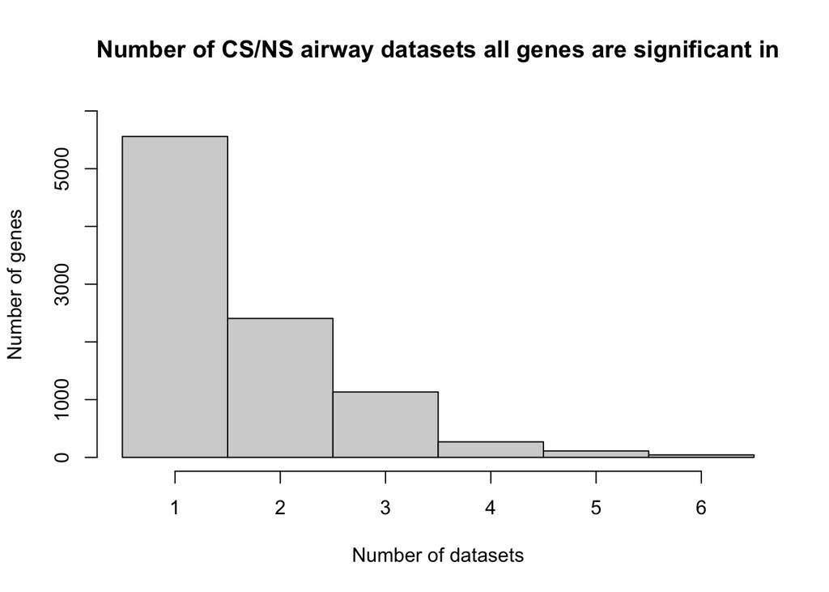

```r
# Histogram of number of studies every gene appears in
hist(CS_NS_ranked_genes$num_studies,
     xlim = c(0.5, 6.5),  # Adjust x-axis limits slightly
     ylim = c(0,6000),
     breaks = seq(0.5, 6.5, by = 1),  # Shift breaks by 0.5
     main = "Number of CS/NS airway datasets all genes are significant in",
     xlab = "Number of datasets",
     ylab = "Number of genes")
```

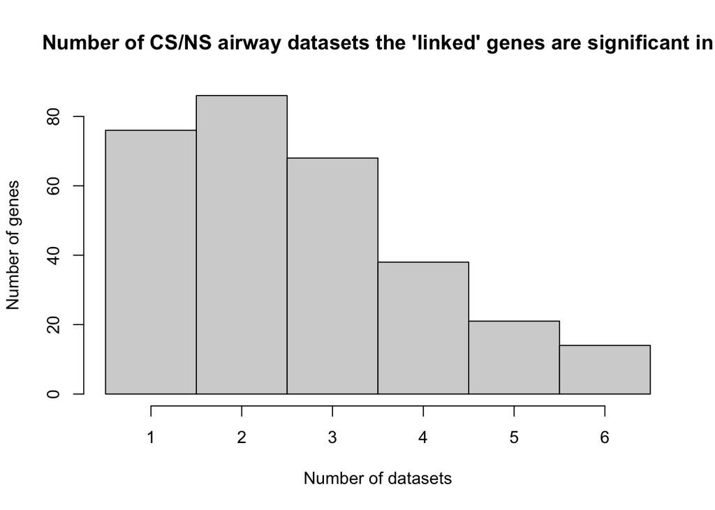

```r
# Filter the ranked genes to the "linked" genes
CS_NS_ranked_genes_linked <- CS_NS_ranked_genes %>%
  filter(Gene.symbol %in% linked_genes$Gene)
# Histogram of number of studies every "linked" gene appears in
hist(CS_NS_ranked_genes_linked$num_studies,
     xlim = c(0.5, 6.5),  # Adjust x-axis limits slightly
     #ylim = c(0,6000),
     breaks = seq(0.5, 6.5, by = 1),  # Shift breaks by 0.5
     main = "Number of CS/NS airway datasets the 'linked' genes are significant in",
     xlab = "Number of datasets",
     ylab = "Number of genes")
```

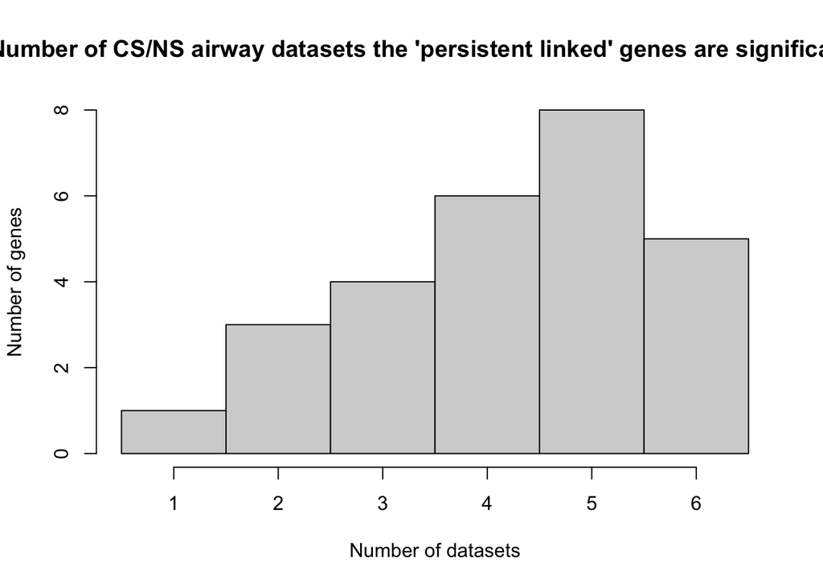

```r
# Filter the ranked genes to the persistent linked genes
CS_NS_ranked_genes_persistent_linked <- CS_NS_ranked_genes %>%
  filter(Gene.symbol %in% persistent_linked_genes$Gene)
# Histogram of number of studies every "persistent linked" gene appears in
hist(CS_NS_ranked_genes_persistent_linked$num_studies,
     xlim = c(0.5, 6.5),  # Adjust x-axis limits slightly
     #ylim = c(0,6000),
     breaks = seq(0.5, 6.5, by = 1),  # Shift breaks by 0.5
     main = "Number of CS/NS airway datasets the 'persistent linked' genes are significant in",
     xlab = "Number of datasets",
     ylab = "Number of genes")
```

# Calculating standard mean difference (SMD)

### getMeanSD: Function to return a table of mean and SD values for each gene in a matrix.

```r
getMeanSD <- function(GSE_readcount_input, current_smoker_indexes, never_smoker_indexes){

    # Make dataframe to contain the info
    GSE_CS_NS_mean_SD <- data.frame(
      ID = rownames(GSE_readcount_input),
      Current_smoker_count = NA,
      Current_smoker_mean = NA,
      Current_smoker_SD = NA,
      Never_smoker_count = NA,
      Never_smoker_mean = NA,
      Never_smoker_SD = NA
    )

    # Loop through each gene and calculate mean and standard deviation
    for (i in 1:nrow(GSE_readcount_input)) { #Looping through rows
      Current_row <- GSE_readcount_input[i,] #Extract the row
      current_smoker_values <- GSE_readcount_input[i, current_smoker_indexes]
      never_smoker_values   <- GSE_readcount_input[i, never_smoker_indexes]

      # Calculate mean and standard deviation for Current_smoker
      current_mean <- mean(as.numeric(current_smoker_values))
      current_sd   <- sd(as.numeric(current_smoker_values))

      # Calculate mean and standard deviation for Never_smoker
      never_mean <- mean(as.numeric(never_smoker_values))
      never_sd   <- sd(as.numeric(never_smoker_values))

      # Add results to the new dataframe
      GSE_CS_NS_mean_SD[i, 2:4] <- c(length(current_smoker_values), current_mean, current_sd)
      GSE_CS_NS_mean_SD[i, 5:7] <- c(length(never_smoker_values), never_mean, never_sd)
    }
    return(GSE_CS_NS_mean_SD)
}

# Save the function
#dump("getMeanSD", file = "./Functions/getMeanSD.R")
```

### Read in the normalized read count information

```r
GSE4302_expr_matrix  <- read.table("../2_Outputs/2_Airway_expression/GSE4302_expr_matrix_20241115.txt", header = T)
GSE4302_sstat_data   <- read.table("../2_Outputs/2_Airway_expression/GSE4302_sstat_data.txt", header = T)
GSE4302_gene_symbol  <- read.table("../2_Outputs/2_Airway_expression/GSE4302_gene_symbol.txt", header = T)

GSE7895_expr_matrix  <- read.table("../2_Outputs/2_Airway_expression/GSE7895_expr_matrix_20241115.txt", header = T)
GSE7895_sstat_data   <- read.table("../2_Outputs/2_Airway_expression/GSE7895_sstat_data.txt", header = T)
GSE7895_gene_symbol  <- read.table("../2_Outputs/2_Airway_expression/GSE7895_gene_symbol.txt", header = T)

GSE14633_expr_matrix <- read.table("../2_Outputs/2_Airway_expression/GSE14633_expr_matrix_20241115.txt", header = T)
GSE14633_sstat_data  <- read.table("../2_Outputs/2_Airway_expression/GSE14633_sstat_data.txt", header = T)
GSE14633_gene_symbol <- read.table("../2_Outputs/2_Airway_expression/GSE14633_gene_symbol.txt", header = T)

GSE19027_expr_matrix <- read.table("../2_Outputs/2_Airway_expression/GSE19027_expr_matrix_20241115.txt", header = T)
GSE19027_sstat_data  <- read.table("../2_Outputs/2_Airway_expression/GSE19027_sstat_data.txt", header = T)
GSE19027_gene_symbol <- read.table("../2_Outputs/2_Airway_expression/GSE19027_gene_symbol.txt", header = T)

GSE20257_expr_matrix <- read.table("../2_Outputs/2_Airway_expression/GSE20257_expr_matrix_20241115.txt", header = T)
GSE20257_sstat_data  <- read.table("../2_Outputs/2_Airway_expression/GSE20257_sstat_data.txt", header = T)
GSE20257_gene_symbol <- read.table("../2_Outputs/2_Airway_expression/GSE20257_gene_symbol.txt", header = T)

GSE63127_expr_matrix <- read.table("../2_Outputs/2_Airway_expression/GSE63127_expr_matrix_20241118.txt", header = T)
GSE63127_sstat_data  <- read.table("../2_Outputs/2_Airway_expression/GSE63127_sstat_data.txt", header = T)
GSE63127_gene_symbol  <- read.table("../2_Outputs/2_Airway_expression/GSE63127_gene_symbol.txt", header = T)
```

### Apply getMeanSD function to CS vs NS comparisons, and add GEO_ID identifier column

```r
## GSE4302
GSE4302_current_smoker_indexes <- which(GSE4302_sstat_data[1]=="current_smoker")
GSE4302_never_smoker_indexes   <- which(GSE4302_sstat_data[1]=="healthy_control")
GSE4302_CS_NS_mean_SD <- getMeanSD(GSE4302_expr_matrix, GSE4302_current_smoker_indexes, GSE4302_never_smoker_indexes)
GSE4302_CS_NS_mean_SD <- cbind(GEO_ID = "GSE4302", GSE4302_CS_NS_mean_SD)
GSE4302_CS_NS_mean_SD$Gene <- GSE4302_gene_symbol$x # Add gene symbol column

# GSE7895
GSE7895_current_smoker_indexes <- which(GSE7895_sstat_data[1]=="current_smoker")
GSE7895_never_smoker_indexes   <- which(GSE7895_sstat_data[1]=="never_smoker")
GSE7895_CS_NS_mean_SD <- getMeanSD(GSE7895_expr_matrix, GSE7895_current_smoker_indexes, GSE7895_never_smoker_indexes)
GSE7895_CS_NS_mean_SD <- cbind(GEO_ID = "GSE7895", GSE7895_CS_NS_mean_SD)
GSE7895_CS_NS_mean_SD$Gene <- GSE7895_gene_symbol$x

# GSE19027
GSE19027_current_smoker_indexes <- which(GSE19027_sstat_data[1]=="current_smoker")
GSE19027_never_smoker_indexes   <- which(GSE19027_sstat_data[1]=="never_smoker")
GSE19027_CS_NS_mean_SD <- getMeanSD(GSE19027_expr_matrix, GSE19027_current_smoker_indexes, GSE19027_never_smoker_indexes)
GSE19027_CS_NS_mean_SD <- cbind(GEO_ID = "GSE19027", GSE19027_CS_NS_mean_SD)
GSE19027_CS_NS_mean_SD$Gene <- GSE19027_gene_symbol$x

# GSE20257
GSE20257_current_smoker_indexes <- which(GSE20257_sstat_data[1]=="smoker")
GSE20257_never_smoker_indexes   <- which(GSE20257_sstat_data[1]=="non.smoker")
GSE20257_CS_NS_mean_SD <- getMeanSD(GSE20257_expr_matrix, GSE20257_current_smoker_indexes, GSE20257_never_smoker_indexes)
GSE20257_CS_NS_mean_SD <- cbind(GEO_ID = "GSE20257", GSE20257_CS_NS_mean_SD)
GSE20257_CS_NS_mean_SD$Gene <- GSE20257_gene_symbol$x

# GSE63127
GSE63127_current_smoker_indexes <- which(GSE63127_sstat_data[1]=="smoker")
GSE63127_never_smoker_indexes   <- which(GSE63127_sstat_data[1]=="non.smoker")
GSE63127_CS_NS_mean_SD <- getMeanSD(GSE63127_expr_matrix, GSE63127_current_smoker_indexes, GSE63127_never_smoker_indexes)
GSE63127_CS_NS_mean_SD <- cbind(GEO_ID = "GSE63127", GSE63127_CS_NS_mean_SD)
GSE63127_CS_NS_mean_SD$Gene <- GSE63127_gene_symbol$x
```

### Apply getMeanSD function to the persistent linked gene list to generate a table of SMD values

```r
library(meta)
## Use the persistent linked genes list as the input genes list
gene_list <- persistent_linked_genes

## Put the dataframes in a list
dataframe_list <- list(GSE4302_CS_NS_mean_SD, GSE7895_CS_NS_mean_SD, GSE19027_CS_NS_mean_SD, GSE20257_CS_NS_mean_SD, GSE63127_CS_NS_mean_SD)


# Make a dataframe as a template that will hold the values for each gene as input to SMD calculation
CS_NS_SMD_input_template <- data.frame(
      GEO_ID = character(0),
    Gene = character(0),
      Current_smoker_count = numeric(0),
      Current_smoker_mean = numeric(0),
      Current_smoker_SD = numeric(0),
      Never_smoker_count = numeric(0),
      Never_smoker_mean = numeric(0),
      Never_smoker_SD = numeric(0)
    )
# Make a dataframe that will have all the SMD output values
persistent_linked_CS_NS_SMD_summary <- data.frame(
  GEO_ID = character(0),
  gene = character(0),
  ID = character(0),
  n_obs = numeric(0),
  SMD = numeric(0),
  CI_95_lower = numeric(0),
  CI_95_upper = numeric(0),
  z_statistic = numeric(0),
  p_value = numeric(0),
  method = character(0)
)

# Loop through the list and extract individual genes
for (i in 1:nrow(gene_list)){ # For each gene on the gene list

  df_SMD_input <- CS_NS_SMD_input_template # Make a new dataframe for data to input into SMD

  for (j in 1:length(dataframe_list)){ # For each dataframe in the list of dataframes
    df <- dataframe_list[[j]] # Extract dataframe j
    # Append the row with the gene of interest to the SMD input dataframe
    df_SMD_input <- rbind(df_SMD_input, df[df$Gene==gene_list[i,]$Gene,])
  }

  for (k in 1:length(df_SMD_input[,1])){ # For all the GSE values in the input
    # Input the resulting df into the SMD calculation function
    df_SMD_values <- metacont(Current_smoker_count, Current_smoker_mean, Current_smoker_SD, Never_smoker_count, Never_smoker_mean, Never_smoker_SD, sm="SMD", data = df_SMD_input, subset=k)


  # Make a summary of the values
    df_SMD_summary <- as.data.frame(t(c(GEO_ID = df_SMD_input[k,1], gene = gene_list$Gene[i], ID = df_SMD_input$ID[k], n_obs = sum(df_SMD_values$n.e, df_SMD_values$n.c), SMD = df_SMD_values$TE, CI_95_lower = df_SMD_values$lower, CI_95_upper =  df_SMD_values$upper, z_stat = df_SMD_values$statistic, p_value = df_SMD_values$pval, method = df_SMD_values$method.smd)))

  # Append results from this to the output dataframe
    persistent_linked_CS_NS_SMD_summary <- rbind(persistent_linked_CS_NS_SMD_summary, df_SMD_summary)
  }
}

head(persistent_linked_CS_NS_SMD_summary)
```

```
##     GEO_ID  gene          ID n_obs               SMD         CI_95_lower
## 1  GSE4302 ALDOA 200966_x_at    44 0.666669952555363  0.0354071250796463
## 2  GSE4302 ALDOA 214687_x_at    44 0.760051848540212   0.123773803600555
## 3  GSE4302 ALDOA 238996_x_at    44 0.400504846977431  -0.219930263419162
## 4  GSE7895 ALDOA 200966_x_at    72  1.31875772212904   0.764509861530615
## 5  GSE7895 ALDOA 214687_x_at    72  1.35675863632039   0.799935605899596
## 6 GSE19027 ALDOA 200966_x_at    30   0.7194668086317 -0.0852818992772924
##        CI_95_upper           z_stat              p_value method
## 1 1.29793278003108 2.06989710103562   0.0384619814826875 Hedges
## 2 1.39632989347987 2.34123157536134   0.0192202413320127 Hedges
## 3 1.02093995737402 1.26520092521476    0.205799310895935 Hedges
## 4 1.87300558272747 4.66346886195692 3.10923249993785e-06 Hedges
## 5 1.91358166674118   4.775661058581 1.79117865448402e-06 Hedges
## 6 1.52421551654069 1.75226007712904   0.0797290974780221 Hedges
```

## Filter the SMD table to the probesets of interest (those that were selected in the DEGs calculations due to having lowest FDR)

```r
## Grab all the probe IDs of interest

dataframe_DEGs_list <- list(GSE4302 = GSE4302_CS_NS_GEO2R_limma_sig, GSE63127 = GSE63127_CS_NS_GEO2R_limma_sig, GSE14633 = GSE14633_CS_NS_GEO2R_limma_sig, GSE19027 = GSE19027_CS_NS_GEO2R_limma_sig, GSE20257 = GSE20257_CS_NS_GEO2R_limma_sig, GSE7895 = GSE7895_CS_NS_GEO2R_limma_sig)

GSE_probeset_gene <- data.frame(GSE = character(0), probeset = character(0), gene = character(0))


## I worked through the logic for this in my head and it is difficult to explain in words
for (i in 1:length(dataframe_DEGs_list)) { # Iterate through all the dataframes of DEGs
  df <- dataframe_DEGs_list[[i]]
  for (j in 1:nrow(gene_list)){
    df_gene_j <- df[df$Gene==gene_list$Gene[j],] # Pull out the rows with gene names in the persistent linked genes list
    df_name <- names(dataframe_DEGs_list[i])
    if (length(df_gene_j$ID)>0) { # If that row existed in this dataframe
      probeset_ID_gene_j <- df_gene_j$ID
      gene_j <- df_gene_j$Gene.symbol
      GSE_probeset_pair_gene_j <- data.frame(df_name, probeset_ID_gene_j, gene_j)
      GSE_probeset_gene <- rbind(GSE_probeset_gene, GSE_probeset_pair_gene_j) # Store the GEO ID, probeset ID, and gene name
    }
  }
}

colnames(GSE_probeset_gene) <- c("GEO_ID", "ID", "gene")

# Now see if this works for filtering the main list
persistent_linked_CS_NS_SMD_summary_ID_filter <- persistent_linked_CS_NS_SMD_summary %>%
  semi_join(GSE_probeset_gene, by = c("GEO_ID", "gene", "ID"))
```

## Cumulative SMDs for each gene (overall summary for a gene, not separated by study)

```r
library(meta)

## Use the persistent linked genes list as the input genes list
gene_list <- persistent_linked_genes

## Put the dataframes in a list
dataframe_list <- list(GSE4302 = GSE4302_CS_NS_mean_SD, GSE7895 = GSE7895_CS_NS_mean_SD, GSE19027 = GSE19027_CS_NS_mean_SD, GSE20257 = GSE20257_CS_NS_mean_SD, GSE63127 = GSE63127_CS_NS_mean_SD)

# Make a dataframe as a template that will hold the values for each gene as input to SMD calculation
CS_NS_SMD_input_template <- data.frame(
      GEO_ID = character(0),
    Gene = character(0),
      Current_smoker_count = numeric(0),
      Current_smoker_mean = numeric(0),
      Current_smoker_SD = numeric(0),
      Never_smoker_count = numeric(0),
      Never_smoker_mean = numeric(0),
      Never_smoker_SD = numeric(0)
    )
# Make a dataframe that will have all the SMD output values
persistent_linked_CS_NS_SMD_summary_overall <- data.frame(
  GEO_ID = character(0),
  gene = character(0),
  n_obs = numeric(0),
  SMD = numeric(0),
  CI_95_lower = numeric(0),
  CI_95_upper = numeric(0),
  z_statistic = numeric(0),
  p_value = numeric(0),
  method = character(0)
)

# Making this to help filter to the probesets of interest
GSE_probeset_gene_for_join <- GSE_probeset_gene
names(GSE_probeset_gene_for_join)[3] <- "Gene"

# Loop through the list and extract individual genes
for (i in 1:nrow(gene_list)){ # For each gene on the gene list

  df_SMD_input <- CS_NS_SMD_input_template # Make a new dataframe for data to input into SMD

  for (j in 1:length(dataframe_list)){ # For each dataframe in the list of dataframes
    df <- dataframe_list[[j]] # Extract dataframe j
    df_gene_j <- df[df$Gene==gene_list[i,]$Gene,]
    df_gene_j <- df_gene_j %>%
      semi_join(GSE_probeset_gene_for_join, by = c("GEO_ID", "Gene", "ID")) # Filtering to probesets of interest from DEGs
    # Append the row with the gene of interest to the SMD input dataframe
    df_SMD_input <- rbind(df_SMD_input, df_gene_j)
  }

  # Input the resulting df into the SMD calculation function
  df_SMD_values <- metacont(Current_smoker_count, Current_smoker_mean, Current_smoker_SD, Never_smoker_count, Never_smoker_mean, Never_smoker_SD, sm="SMD", data = df_SMD_input)


  # Make a summary of the values
      df_SMD_summary_overall <- as.data.frame(t(c(gene = gene_list$Gene[i], n_studies = df_SMD_values$k, n_obs = sum(df_SMD_values$n.e.pooled, df_SMD_values$n.c.pooled), SMD_common= df_SMD_values$TE.common, CI_95_lower_common = df_SMD_values$lower.common, CI_95_upper_common =  df_SMD_values$upper.common, z_stat_common = df_SMD_values$statistic.common, p_value_common = df_SMD_values$pval.common, SMD_random= df_SMD_values$TE.random, CI_95_lower_random = df_SMD_values$lower.random, CI_95_upper_random =  df_SMD_values$upper.random, z_stat_random = df_SMD_values$statistic.random, p_value_random = df_SMD_values$pval.random, method = df_SMD_values$method.smd, Q = df_SMD_values$Q, Q_df = df_SMD_values$df.Q,  Q_pval = df_SMD_values$pval.Q)))

  # Append results from this to the output dataframe
  persistent_linked_CS_NS_SMD_summary_overall <- rbind(persistent_linked_CS_NS_SMD_summary_overall, df_SMD_summary_overall)

}

head(persistent_linked_CS_NS_SMD_summary_overall)
```

```
##      gene n_studies n_obs         SMD_common CI_95_lower_common
## 1   ALDOA         3   349  0.974972127745496  0.745025802954437
## 2    CA12         5   423   1.25295797335045   1.03479933845881
## 3  CCDC81         5   423 -0.962175928735645  -1.17288712172326
## 4 CEACAM5         5   423   2.00510197011682   1.76236827937362
## 5 CEACAM6         5   423   1.78747032908204   1.55338364248522
## 6 CTNNAL1         4   393  -1.12743918358708  -1.34937151170678
##   CI_95_upper_common     z_stat_common       p_value_common        SMD_random
## 1   1.20491845253656  8.31024482799586  9.5504822639963e-17 0.987119908745656
## 2    1.4711166082421  11.2567284037549 2.14577609445646e-29   1.5531958155316
## 3 -0.751464735748031 -8.94983384781128 3.56017823210304e-19 -1.17778120562584
## 4   2.24783566086003  16.1902850598391 5.90543639281198e-59  2.15457780866811
## 5   2.02155701567886  14.9661542882565 1.22185370278427e-50  1.78747089493542
## 6 -0.905506855467389 -9.95681978065924 2.35474776046705e-23 -1.35022438298879
##   CI_95_lower_random CI_95_upper_random     z_stat_random       p_value_random
## 1  0.600667527749133   1.37357228974218  5.00635929470791 5.54691751439163e-07
## 2  0.964123967388722   2.14226766367448  5.16780401062705  2.3686049503168e-07
## 3  -1.64991057173725 -0.705651839514426 -4.88935641455115  1.0116618239232e-06
## 4   1.75049100406999   2.55866461326623  10.4504647487278  1.4580894917121e-25
## 5   1.55337942296907   2.02156236690176  14.9658530832368 1.22739853777229e-50
## 6  -1.96068196196233 -0.739766804015241 -4.33509428477506 1.45697660785568e-05
##   method                Q Q_df              Q_pval
## 1 Hedges 4.91119708313048    2  0.0858118181270338
## 2 Hedges 15.5812801460672    4 0.00363570388530808
## 3 Hedges 13.1781279800065    4  0.0104374421881997
## 4 Hedges 8.49305264916706    4  0.0750980925430408
## 5 Hedges 6.20796342027422    4   0.184146423329469
## 6 Hedges 12.5456105287783    3 0.00572976561004082
```